# Fordgobike Slide Deck

This document explores a dataset describing fordgobike which is a regional public bicycle sharing system in San Francisco

```python
# import all packages and set plots to be embedded inline
import numpy as np
import pandas as pd
import matplotlib.pyplot as plt
import seaborn as sns

default_color = sns.color_palette()[0]
%matplotlib inline

import warnings
warnings.simplefilter("ignore")
```

```python
# load in the dataset into a pandas dataframe, print statistics
ford_df = pd.read_csv('201902-fordgobike-tripdata.csv')

clean_df = ford_df.dropna()


clean_df['start_time'] = pd.to_datetime(clean_df['start_time'])
clean_df['end_time'] = pd.to_datetime(clean_df['end_time'])

#from start and end time as month & day of week & hour
clean_df['start_day'] = clean_df['start_time'].dt.strftime('%A')
clean_df['start_month'] = clean_df['start_time'].dt.strftime('%B')
clean_df['start_hour'] = clean_df['start_time'].dt.strftime('%H')

#from start and end time as year & month & day of week & hour
clean_df['end_day'] = clean_df['end_time'].dt.strftime('%A')
clean_df['end_month'] = clean_df['end_time'].dt.strftime('%B')
clean_df['end_hour'] = clean_df['end_time'].dt.strftime('%H')

# member age and duration in minutes
start_year = clean_df['start_time'].dt.year[0]
clean_df['member_age'] = start_year - clean_df['member_birth_year']
clean_df['duration_minutes'] = clean_df['duration_sec']/60
clean_df['duration_minutes'] = clean_df['duration_minutes'].astype('int')

categoric_cols = [col for col in clean_df.columns if clean_df[col].dtype == "object"]
datetime_cols = [col for col in clean_df.columns if clean_df[col].dtype == "datetime64[ns]"]
numeric_cols = [col for col in clean_df.columns if col not in categoric_cols and col not in datetime_cols]
len(numeric_cols) + len(categoric_cols) + len(datetime_cols)

clean_df = clean_df.query('duration_sec < 3000')
clean_df = clean_df.query('member_age < 70')

def plot_column_counts(col_name):
    print(ford_df[col_name].value_counts())
    _ = ford_df[col_name].value_counts().plot(kind='bar')
    _ = plt.title(f'{col_name} distribution')
    _ = plt.xlabel(f'{col_name} user_type')
    _ = plt.ylabel('count')

def plot_hist(col_name, binsize=500):
    # plotting the histogram
    print(clean_df[col_name].describe())

    bins = np.arange(0, clean_df[col_name].max()+binsize, binsize)

    plt.figure(figsize=[8, 5])
    plt.hist(data = clean_df, x = col_name, bins = bins)
    plt.xlabel(col_name)
    plt.ylabel('Count')
    plt.title(f'{col_name} Distribution')
    plt.show()

def plot_count(col_name):
    plt.figure(figsize=[8, 5])
    sns.countplot(data = clean_df, x = col_name, color = default_color)
    plt.title(f"{col_name} distribution")
    plt.show()

def plot_scatter(col1, col2):
    plt.scatter(clean_df[col1], clean_df[col2], alpha = 0.2, marker='.');
    plt.title(f'Scatter plot for {col1} vs {col2}')
    plt.xlabel(col1)
    plt.ylabel(col2)
    plt.show()

def plot_heatmap(col1, col2):
    plt.hist2d(data=clean_df, x=col1, y=col2);
    plt.colorbar();
    plt.title(f'Heatmap for {col1} vs {col2}')
    plt.xlabel(col1)
    plt.ylabel(col2)
    plt.show()
```

## Gender Distribution in Dataset

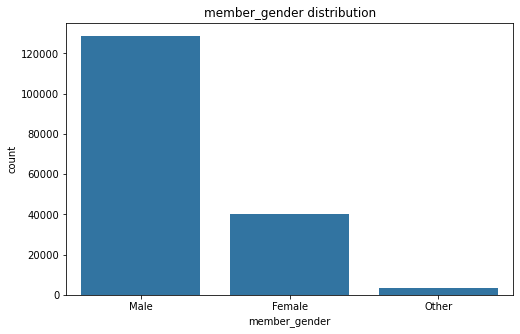

```python
plot_count('member_gender')
```

## duration with gender

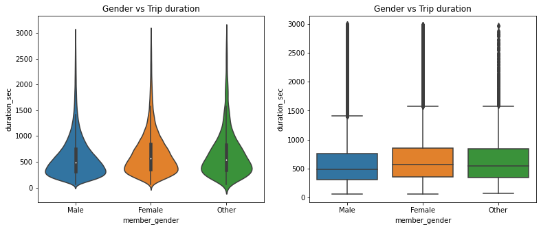

```python
plt.figure(figsize = [13, 5])

plt.subplot(1, 2, 1)
plt.title('Gender vs Trip duration')
sns.violinplot(data=clean_df, x='member_gender', y='duration_sec');
plt.subplot(1, 2, 2)
plt.title('Gender vs Trip duration')
sns.boxplot(data=clean_df, x='member_gender', y='duration_sec');
plt.show()
```

## It seems that All genders have nearly the same duration distribution But The median value for female is slightly higher than male and other

## duration with user_type

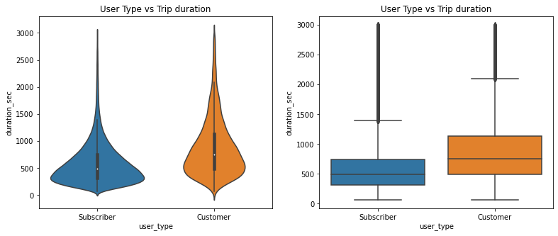

```python
plt.figure(figsize = [13, 5])

plt.subplot(1, 2, 1)
plt.title('User Type vs Trip duration')
sns.violinplot(data=clean_df, x='user_type', y='duration_sec');
plt.subplot(1, 2, 2)
plt.title('User Type vs Trip duration')
sns.boxplot(data=clean_df, x='user_type', y='duration_sec');
plt.show()
```

## It is clear the on average customers have longer trips than subscribers

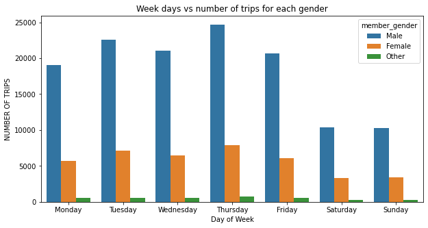

```python
fig=plt.figure(figsize=(10,5))
ORDER=['Monday', 'Tuesday', 'Wednesday', 'Thursday', 'Friday', 'Saturday', 'Sunday']

sns.countplot(data=clean_df, x='start_day', hue='member_gender', order=ORDER)
plt.xlabel('Day of Week')
plt.ylabel('NUMBER OF TRIPS')
plt.title('Week days vs number of trips for each gender');
```

## It seems that Males and females tend to have lower trips on weekends

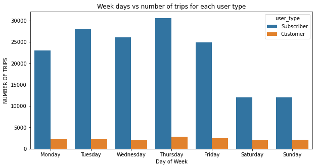

```python
fig=plt.figure(figsize=(10,5))
ORDER=['Monday', 'Tuesday', 'Wednesday', 'Thursday', 'Friday', 'Saturday', 'Sunday']

sns.countplot(data=clean_df, x='start_day', hue='user_type', order=ORDER)
plt.xlabel('Day of Week')
plt.ylabel('NUMBER OF TRIPS')
plt.title('Week days vs number of trips for each user type');
```

## It seems that Subscriber users also have lower trips on week ends But for Customer users all days tend to be the same

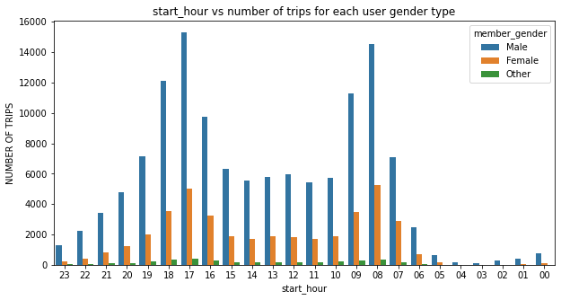

```python
fig=plt.figure(figsize=(10,5))

sns.countplot(data=clean_df, x='start_hour', hue='member_gender')
plt.xlabel('start_hour')
plt.ylabel('NUMBER OF TRIPS')
plt.title('start_hour vs number of trips for each user gender type');
```

## It seems that also that Males and females have top number of trips at 17 and 8 hours due to work hours

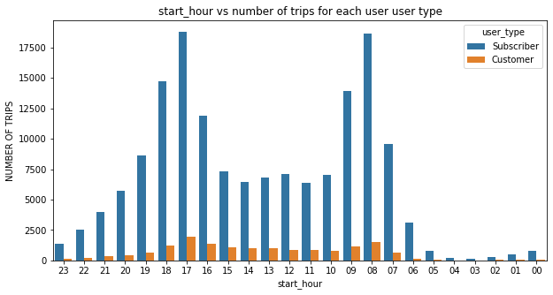

```python
fig=plt.figure(figsize=(10,5))

sns.countplot(data=clean_df, x='start_hour', hue='user_type')
plt.xlabel('start_hour')
plt.ylabel('NUMBER OF TRIPS')
plt.title('start_hour vs number of trips for each user user type');
```

## It seems that also that Subscriber users also have top number of trips at 17 and 8 hours due to work hours. But customer users slightly difference in most hours except from 23 to 6 the trips are very rare

## Trip duration with member_gender

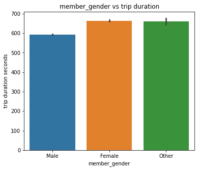

```python
fig=plt.figure(figsize=(6,5))

sns.barplot(data = clean_df, x = 'member_gender', y = 'duration_sec');
plt.xlabel('member_gender')
plt.ylabel('trip duration seconds')
plt.title('member_gender vs trip duration');
```

## It seems that females have trip duration more than males

## Trip duration with user_type

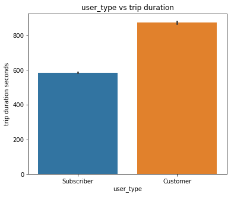

```python
fig=plt.figure(figsize=(6,5))

sns.barplot(data = clean_df, x = 'user_type', y = 'duration_sec');
plt.xlabel('user_type')
plt.ylabel('trip duration seconds')
plt.title('user_type vs trip duration');
```

## It seems that Customers have trip duration more than Subscribers

## Age with duration for each day

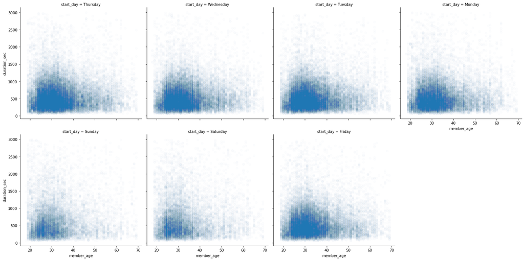

```python
FacetGrid = sns.FacetGrid(data=clean_df, col='start_day', col_wrap=4, height=5);
FacetGrid.map(plt.scatter, 'member_age', 'duration_sec', alpha=0.01);
```

## It seems ages around from 20 to 40 years who are at working age have most of trips

```python
jupyter nbconvert fordgobike-slide_deck.ipynb --to slides --post serve --no-input --no-prompt
```